# eda_feature_extraction

##### Feature extraction and EDA

|  | url | type |
| --- | --- | --- |
| 0 | br-icloud.com.br | phishing |
| 1 | mp3raid.com/music/krizz_kaliko.html | benign |
| 2 | bopsecrets.org/rexroth/cr/1.htm | benign |
| 3 | http://www.garage-pirenne.be/index.php?option=... | defacement |
| 4 | http://adventure-nicaragua.net/index.php?optio... | defacement |

|  | url | type |
| --- | --- | --- |
| count | 651191 | 651191 |
| unique | 641119 | 4 |
| top | http://style.org.hc360.com/css/detail/mysite/s... | benign |
| freq | 180 | 428103 |

```
type
benign        428103
defacement     96457
phishing       94111
malware        32520
Name: count, dtype: int64
```

## EDA

##### 1. count of label

[output not shown]

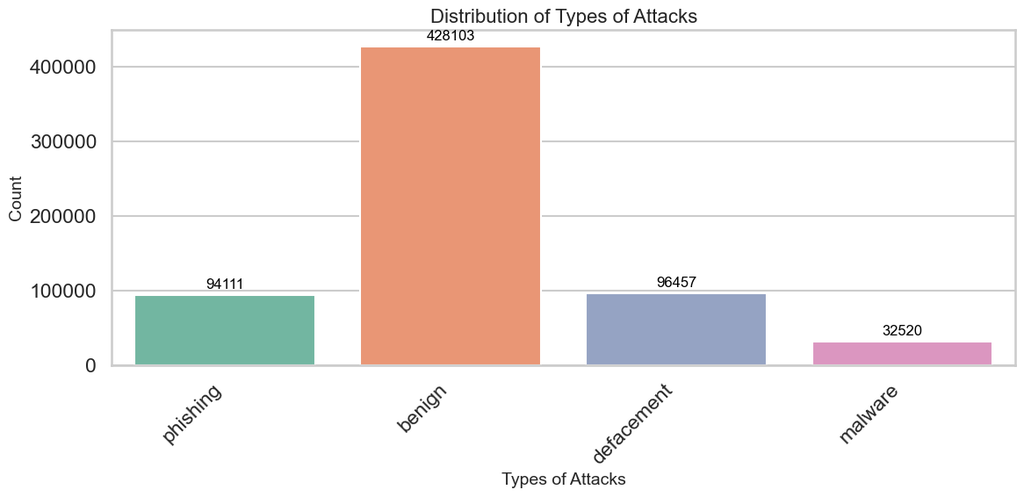

### WordCloud of Different Types of Attacks

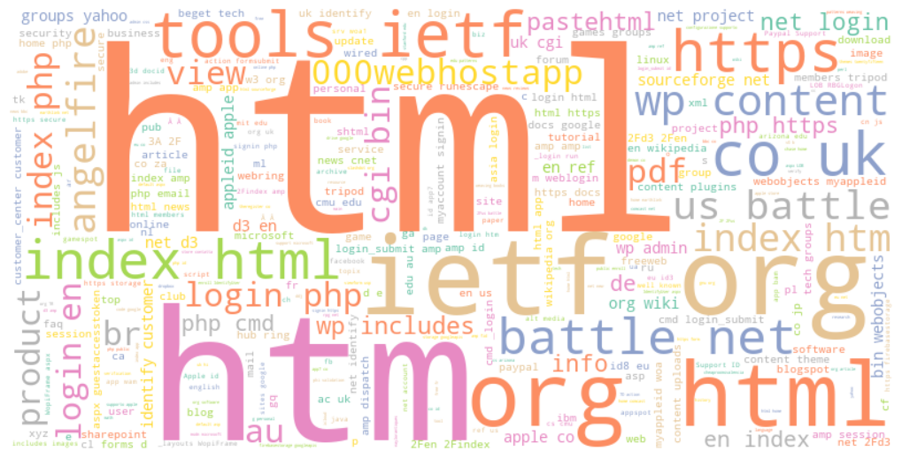

```python
df_benign = df[df['type'] == 'benign']
```

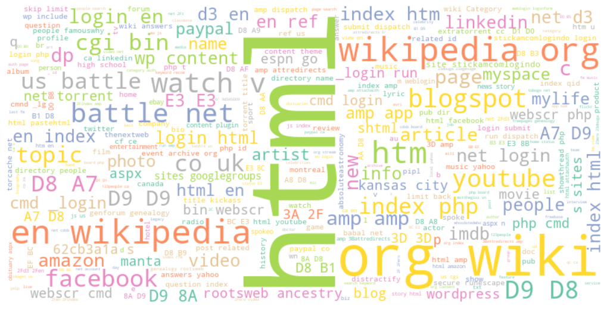

```python
df_deface = df[df['type'] == 'defacement']
```

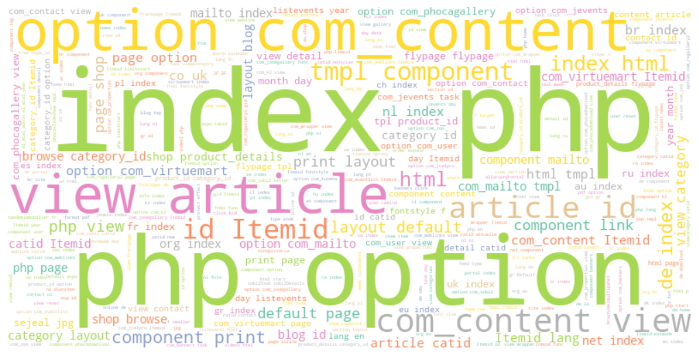

```python
df_malware = df[df['type'] == 'malware']
```

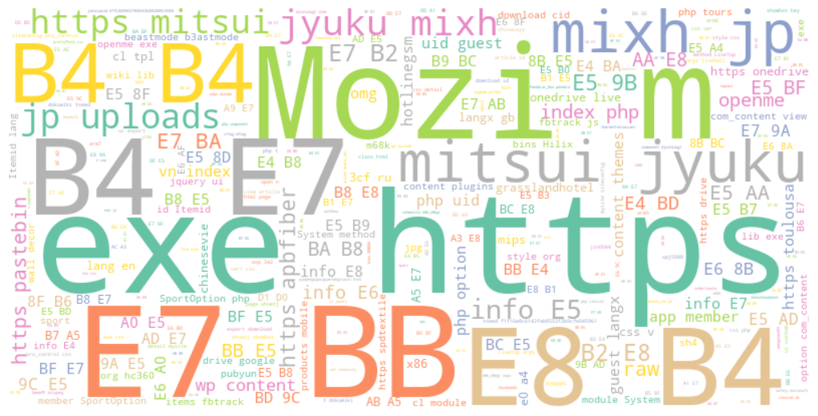

### No we will do the feature engineering

having_ip_address: Generally cyber attackers use an IP address in place of the domain name to hide the identity of the website. this feature will check whether the URL has IP address or not.

```
use_of_ip
0    643898
1      7293
Name: count, dtype: int64
```

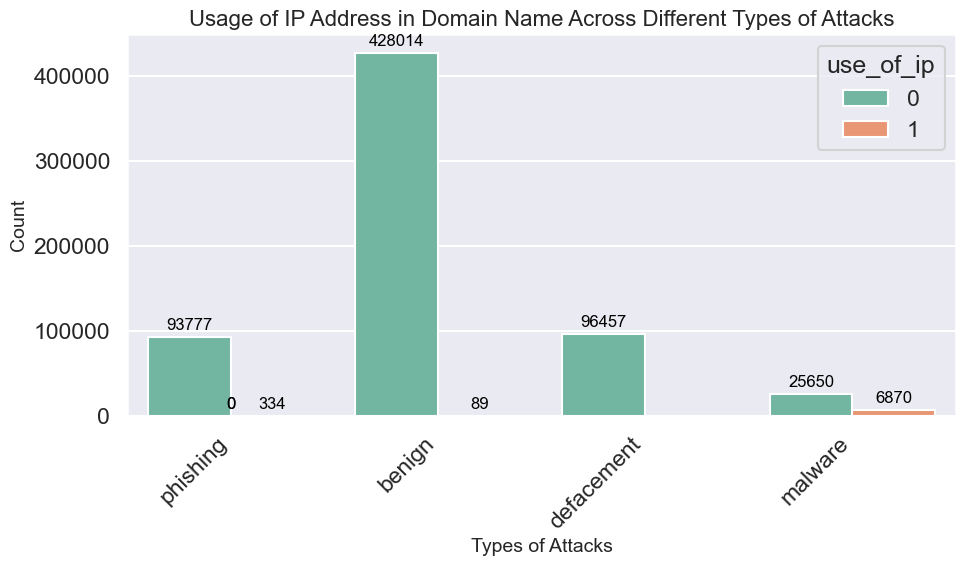

Abnormal URL This feature can be extracted from the WHOIS database. For a legitimate website, identity is typically part of its URL.

```
abnormal_url
0    463185
1    188006
Name: count, dtype: int64
```

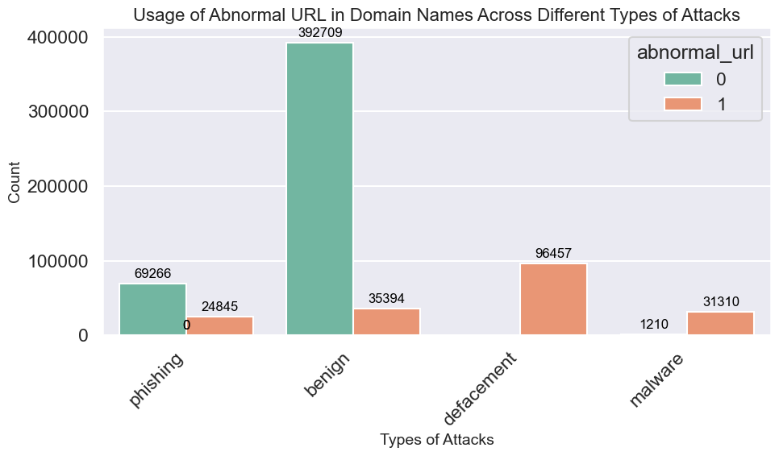

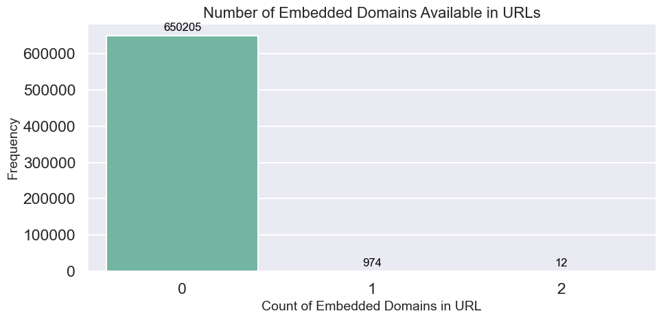

Suspicious words in URL: Malicious URLs generally contain suspicious words in the URL such as PayPal, login, sign in, bank, account, update, bonus, service, ebayisapi, token, etc. We have found the presence of such frequently occurring suspicious words in the URL as a binary variable i.e., whether such words present in the URL or not.

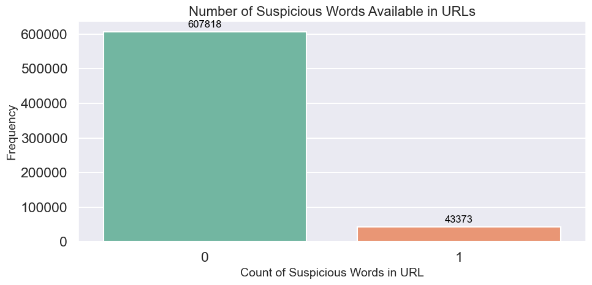

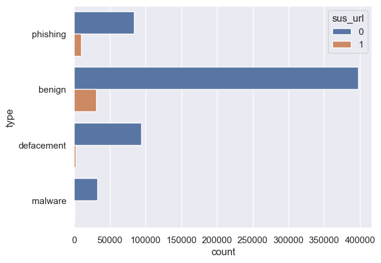

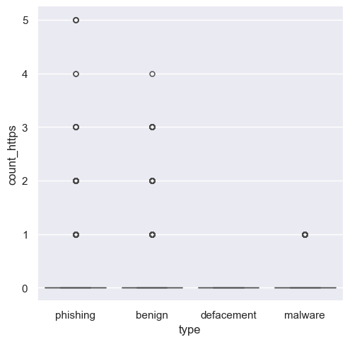

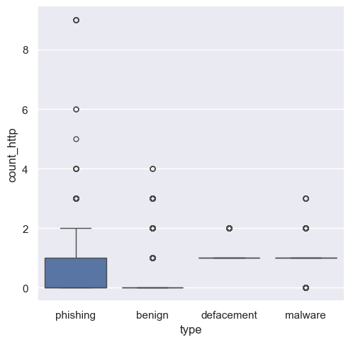

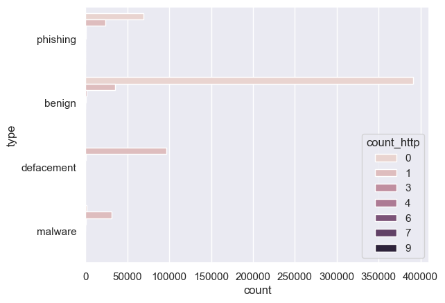

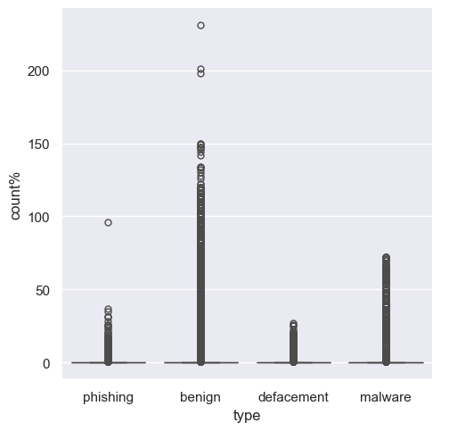

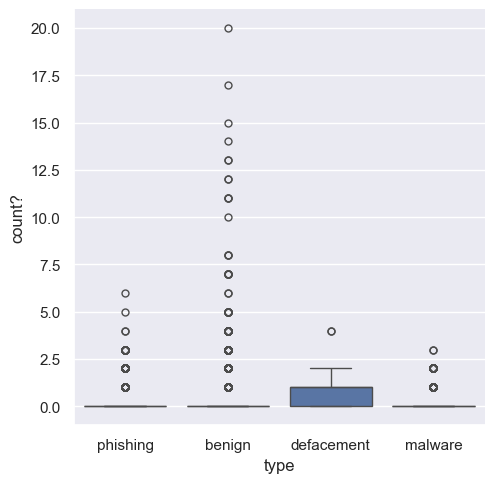

Count-: Phishers or cybercriminals generally add dashes(-) in prefix or suffix of the brand name so that it looks genuine URL. For example. www.flipkart-india.com.

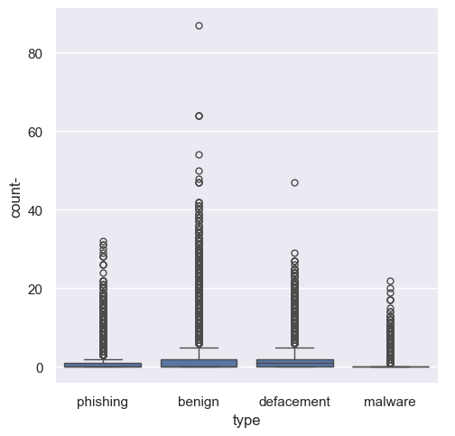

Count=: Presence of equal to (=) in URL indicates passing of variable values from one form page to another. It is considered as riskier in URL as anyone can change the values to modify the page.

url_length: Attackers generally use long URLs to hide the domain name. We found the average length of a safe URL is 74.

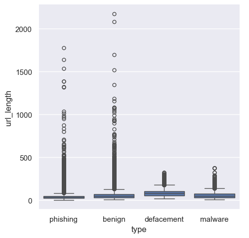

hostname_length: The length of the hostname is also an important feature for detecting malicious URLs.

First directory length: This feature helps in determining the length of the first directory in the URL. So looking for the first ‘/’ and counting the length of the URL up to this point helps in finding the first directory length of the URL. For accessing directory level information we need to install python library TLD. You can check this link for installing TLD.

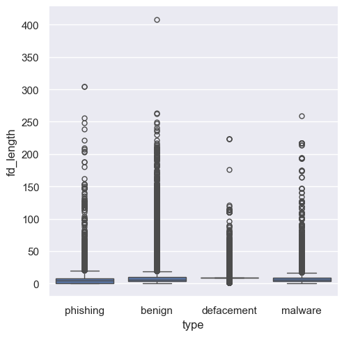

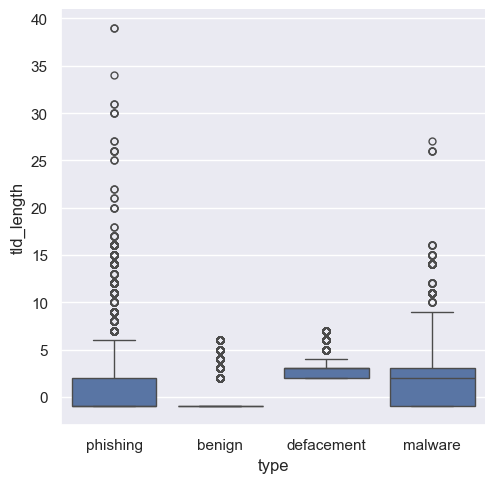

Count_digits: The presence of digits in URL generally indicate suspicious URLs. Safe URLs generally do not have digits so counting the number of digits in URL is an important feature for detecting malicious URLs.

Count_letters: The number of letters in the URL also plays a significant role in identifying malicious URLs. As attackers try to increase the length of the URL to hide the domain name and this is generally done by increasing the number of letters and digits in the URL.

|  | url | type | use_of_ip | abnormal_url | google_index | count. | count-www | count@ | count_dir | count_embed_domain | ... | count? | count- | count= | url_length | hostname_length | fd_length | tld | tld_length | count_digits | count_letters |
| --- | --- | --- | --- | --- | --- | --- | --- | --- | --- | --- | --- | --- | --- | --- | --- | --- | --- | --- | --- | --- | --- |
| 0 | br-icloud.com.br | phishing | 0 | 0 | 1 | 2 | 0 | 0 | 0 | 0 | ... | 0 | 1 | 0 | 16 | 0 | 0 | None | -1 | 0 | 13 |
| 1 | mp3raid.com/music/krizz_kaliko.html | benign | 0 | 0 | 1 | 2 | 0 | 0 | 2 | 0 | ... | 0 | 0 | 0 | 35 | 0 | 5 | None | -1 | 1 | 29 |
| 2 | bopsecrets.org/rexroth/cr/1.htm | benign | 0 | 0 | 1 | 2 | 0 | 0 | 3 | 0 | ... | 0 | 0 | 0 | 31 | 0 | 7 | None | -1 | 1 | 25 |
| 3 | http://www.garage-pirenne.be/index.php?option=... | defacement | 0 | 1 | 1 | 3 | 1 | 0 | 1 | 0 | ... | 1 | 1 | 4 | 88 | 21 | 9 | be | 2 | 7 | 63 |
| 4 | http://adventure-nicaragua.net/index.php?optio... | defacement | 0 | 1 | 1 | 2 | 0 | 0 | 1 | 0 | ... | 1 | 1 | 3 | 235 | 23 | 9 | net | 3 | 22 | 199 |

5 rows × 25 columns

Use of IP Address vs. URL Type

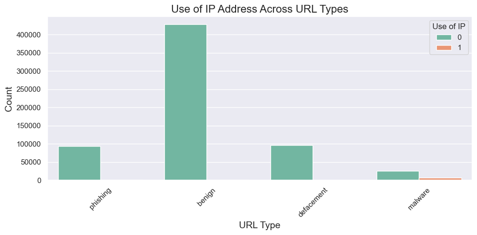

Relationship Between URL Length and Abnormal URL

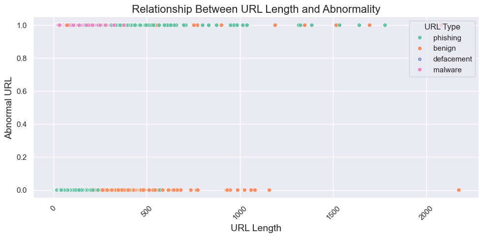

Count of Suspicious Characters in URLs A bar plot to visualize the frequency of suspicious characters in URLs.

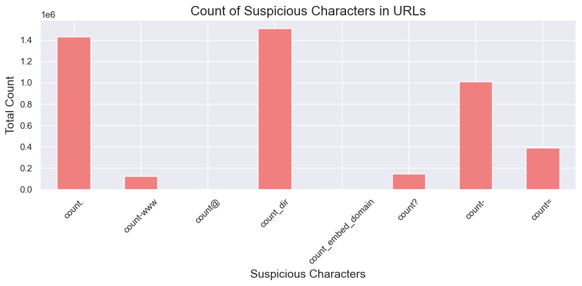

Correlation Heatmap

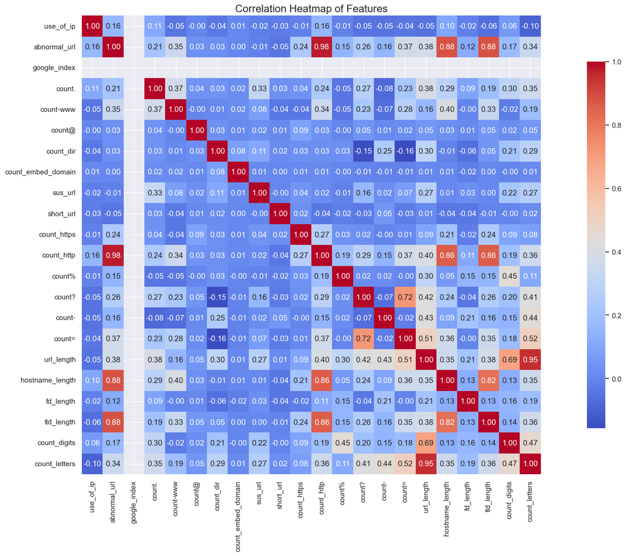